# Analyzing Election Contributions in West Virginia by Michael Kuehn

Prior to conducting an analysis using R, the data was reviewed and audited in Python. Please see Python code. I noticed that there were a wide range of occupations that people had inputted while making their contributions. In order to have a more meaningful analysis regarding contributor’s occupations, I classified occupations into general categories (e.g. MEDICAL, EDUCATION, RETIRED, etc.). The original data was read into a Python script and a new csv file was output with occupation categories. Any contributions that were negative numbers were skipped since these are refunds. The focus is on contributions made to judge the excitement and engagment of individual donors during the election cycle.

The first stage of the analysis is to look at a summary of the data. Most of the columns in the data are categorical variables. Tables were created for each of these variables to examine the counts and relative frequencies within the data. The contribution amount is a quantitative varible and will be analyzed using measures of center and spread.

The following columns will be explored in this analysis: ‘cand_nm’,‘contbr_city’, ‘contbr_employer’, ‘contbr_occupation’, ‘occupation_category’, ‘contb_receipt_amt’, ‘contb_receipt_dt’, and ‘election_tp’

The code block below includes the structure of the data, a summary of the data, and two sets of tables. The first table lists the top 10 (if there are 10 categories) counts for each of the columns. The second table lists the same information but as percentages. A table of some detailed summary statistics for the quantitative variable ‘contb_receipt_amt’ is also included.

```
## 'data.frame':    9109 obs. of  19 variables:
##  $ cmte_id            : Factor w/ 18 levels "C00430470","C00430512",..: 16 17 16 14 14 14 14 14 14 14 ...
##  $ cand_id            : Factor w/ 17 levels "P00003186","P00003251",..: 7 1 7 17 17 17 17 17 17 17 ...
##  $ cand_nm            : Factor w/ 17 levels "Biden, Joseph R Jr",..: 13 17 13 8 8 8 8 8 8 8 ...
##  $ contbr_nm          : Factor w/ 2880 levels "ABRAHAM, LAUREL",..: 2168 600 2736 2329 2126 2126 2126 2126 2126 2126 ...
##  $ contbr_city        : Factor w/ 347 levels "ALBRIGHT","ALDERSON",..: 214 222 282 19 32 32 32 32 32 32 ...
##  $ contbr_st          : Factor w/ 1 level "WV": 1 1 1 1 1 1 1 1 1 1 ...
##  $ contbr_zip         : int  252650336 259019766 24976 25801 25818 25818 25818 25818 25818 25818 ...
##  $ contbr_employer    : Factor w/ 1265 levels "","(NONE)","3M HEALTH INFORMATION SYSTEMS",..: 40 490 403 1 465 465 465 465 465 465 ...
##  $ contbr_occupation  : Factor w/ 858 levels "","227 CAPITOL ST",..: 258 395 301 698 510 510 510 510 510 510 ...
##  $ occupation_category: Factor w/ 12 levels "EDUCATION","EXECUTIVE",..: 6 6 6 9 1 1 1 1 1 1 ...
##  $ contb_receipt_amt  : num  20 2300 25 50 11 5.18 5 15 1 2.98 ...
##  $ contb_receipt_dt   : Factor w/ 601 levels "1-Apr-07","1-Apr-08",..: 338 407 257 599 55 94 114 132 132 206 ...
##  $ receipt_desc       : Factor w/ 10 levels "","REATTRIBUTION / REDESIGNATION REQUESTED (AUTOMATIC)",..: 1 1 1 1 1 1 1 1 1 1 ...
##  $ memo_cd            : Factor w/ 2 levels "","X": 1 1 1 1 1 1 1 1 1 1 ...
##  $ memo_text          : Factor w/ 21 levels "","* EARMARKED CONTRIBUTION: SEE BELOW",..: 1 1 1 1 1 1 1 1 1 1 ...
##  $ form_tp            : Factor w/ 2 levels "SA17A","SA18": 1 1 1 1 1 1 1 1 1 1 ...
##  $ file_num           : int  336959 313015 336959 330012 330012 330012 330012 330012 330012 330012 ...
##  $ tran_id            : Factor w/ 9109 levels "10000477","10002226",..: 2761 8306 3006 8683 8693 8695 8696 8697 8698 8699 ...
##  $ election_tp        : Factor w/ 2 levels "G2008","P2008": 2 2 2 2 2 2 2 2 2 2 ...
```

```
##       cmte_id          cand_id                        cand_nm
##  C00431445:5090   P80003338:5090   Obama, Barack          :5090
##  C00431569:1601   P00003392:1601   Clinton, Hillary Rodham:1601
##  C00430470:1084   P80002801:1316   McCain, John S         :1316
##  C00431205: 303   P40002347: 303   Edwards, John          : 303
##  C00432914: 252   P80000748: 252   Paul, Ron              : 252
##  C00446104: 232   P80003478: 127   Huckabee, Mike         : 127
##  (Other)  : 547   (Other)  : 420   (Other)                : 420
##                    contbr_nm           contbr_city   contbr_st
##  BRADLEY, ROBERT        :  59   CHARLESTON   :1379   WV:9109
##  STERNS, CAROLYN        :  54   MORGANTOWN   : 936
##  HURSH, DANIEL          :  49   HUNTINGTON   : 507
##  JENNINGS, ALAN         :  42   SHEPHERDSTOWN: 364
##  PARANAC, LEONARD R. MR.:  39   WHEELING     : 262
##  RINKER, SARAH          :  37   HARPERS FERRY: 253
##  (Other)                :8829   (Other)      :5408
##    contbr_zip                     contbr_employer
##  Min.   :        0   NOT EMPLOYED         :1996
##  1st Qu.:253032811   SELF EMPLOYED        : 898
##  Median :254431113   RETIRED              : 571
##  Mean   :230780799                        : 311
##  3rd Qu.:261439340   INFORMATION REQUESTED: 268
##  Max.   :268840007   (Other)              :5054
##                      NA's                 :  11
##              contbr_occupation occupation_category contb_receipt_amt
##  RETIRED              :2484    OTHER     :2774     Min.   :   1.0
##  ATTORNEY             : 603    RETIRED   :2489     1st Qu.:  30.0
##  PHYSICIAN            : 373    MEDICAL   :1469     Median : 100.0
##  NOT EMPLOYED         : 225    EDUCATION : 797     Mean   : 214.7
##  INFORMATION REQUESTED: 203    EXECUTIVE : 785     3rd Qu.: 200.0
##  (Other)              :5215    UNEMPLOYED: 239     Max.   :4600.0
##  NA's                 :   6    (Other)   : 556
##   contb_receipt_dt                                receipt_desc  memo_cd
##  30-Sep-08: 170                                         :8692    :8575
##  16-Oct-08: 135    REDESIGNATION FROM PRIMARY           : 207   X: 534
##  31-Oct-08: 122    REATTRIBUTION/REDESIGNATION REQUESTED:  82
##  23-Oct-08: 101    REDESIGNATION TO                     :  56
##  31-Jul-08: 101    REDESIGNATION REQUESTED              :  48
##  24-Oct-08: 100    REATTRIBUTION REQUESTED              :  13
##  (Other)  :8380    (Other)                              :  11
##                                  memo_text     form_tp
##                                       :8291   SA17A:8587
##  OVF TRANSFER                         : 298   SA18 : 522
##  REDESIGNATION FROM PRIMARY           : 207
##  REATTRIBUTION/REDESIGNATION REQUESTED:  82
##  ORIGINAL TRANSACTION                 :  57
##  REDESIGNATION TO                     :  56
##  (Other)                              : 118
##     file_num          tran_id     election_tp
##  Min.   :294891   10000477:   1   G2008:2790
##  1st Qu.:353643   10002226:   1   P2008:6319
##  Median :753761   10003971:   1
##  Mean   :597425   10006491:   1
##  3rd Qu.:753821   10008089:   1
##  Max.   :877004   10008114:   1
##                   (Other) :9103
```

```
## $cand_nm
## x
##           Obama, Barack Clinton, Hillary Rodham          McCain, John S
##                    5090                    1601                    1316
##           Edwards, John               Paul, Ron          Huckabee, Mike
##                     303                     252                     127
##            Romney, Mitt     Giuliani, Rudolph W   Thompson, Fred Dalton
##                     109                      98                      68
##  Brownback, Samuel Dale
##                      46
##
## $contbr_city
## x
##    CHARLESTON    MORGANTOWN    HUNTINGTON SHEPHERDSTOWN      WHEELING
##          1379           936           507           364           262
## HARPERS FERRY   MARTINSBURG       BECKLEY   PARKERSBURG  CHARLES TOWN
##           253           251           200           188           165
##
## $contbr_employer
## x
##                           NOT EMPLOYED
##                                   1996
##                          SELF EMPLOYED
##                                    898
##                                RETIRED
##                                    571
##
##                                    311
##                  INFORMATION REQUESTED
##                                    268
##               WEST VIRGINIA UNIVERSITY
##                                    262
##                          SELF-EMPLOYED
##                                    242
## INFORMATION REQUESTED PER BEST EFFORTS
##                                    107
##                                   SELF
##                                     93
##                                   NONE
##                                     79
```

[output cut: 15 more lines]

```
##       2774       2489       1469        797        785        239
##  HOMEMAKER      LEGAL    STUDENT  POLITICAL
##        211        162         57         50
##
## $contb_receipt_dt
## x
## 30-Sep-08 16-Oct-08 31-Oct-08 23-Oct-08 31-Jul-08 24-Oct-08 30-Aug-08
##       170       135       122       101       101       100        98
## 29-Sep-08 30-Oct-08 31-Aug-08
##        94        86        85
##
## $election_tp
## x
## P2008 G2008  <NA>  <NA>  <NA>  <NA>  <NA>  <NA>  <NA>  <NA>
##  6319  2790    NA    NA    NA    NA    NA    NA    NA    NA
```

```
## $cand_nm
## x
##           Obama, Barack Clinton, Hillary Rodham          McCain, John S
##              55.8788012              17.5760237              14.4472500
##           Edwards, John               Paul, Ron          Huckabee, Mike
##               3.3263805               2.7664947               1.3942255
##            Romney, Mitt     Giuliani, Rudolph W   Thompson, Fred Dalton
##               1.1966187               1.0758590               0.7465144
##  Brownback, Samuel Dale
##               0.5049951
##
## $contbr_city
## x
##    CHARLESTON    MORGANTOWN    HUNTINGTON SHEPHERDSTOWN      WHEELING
##     15.138874     10.275552      5.565924      3.996048      2.876276
## HARPERS FERRY   MARTINSBURG       BECKLEY   PARKERSBURG  CHARLES TOWN
##      2.777473      2.755517      2.195631      2.063893      1.811395
##
## $contbr_employer
## x
##                           NOT EMPLOYED
##                             21.9123943
##                          SELF EMPLOYED
##                              9.8583818
##                                RETIRED
##                              6.2685256
##
##                              3.4142057
##                  INFORMATION REQUESTED
##                              2.9421451
##               WEST VIRGINIA UNIVERSITY
##                              2.8762762
##                          SELF-EMPLOYED
##                              2.6567131
## INFORMATION REQUESTED PER BEST EFFORTS
##                              1.1746624
##                                   SELF
##                              1.0209683
##                                   NONE
##                              0.8672741
```

[output cut: 17 more lines]

```
##  2.3163904  1.7784609  0.6257547  0.5489077
##
## $contb_receipt_dt
## x
## 30-Sep-08 16-Oct-08 31-Oct-08 23-Oct-08 31-Jul-08 24-Oct-08 30-Aug-08
## 1.8662861 1.4820507 1.3393347 1.1087935 1.1087935 1.0978153 1.0758590
## 29-Sep-08 30-Oct-08 31-Aug-08
## 1.0319464 0.9441212 0.9331430
##
## $election_tp
## x
##    P2008    G2008     <NA>     <NA>     <NA>     <NA>     <NA>     <NA>
## 69.37095 30.62905       NA       NA       NA       NA       NA       NA
##     <NA>     <NA>
##       NA       NA
```

```
##      nbr.val     nbr.null       nbr.na          min          max
##       9109.0          0.0          0.0          1.0       4600.0
##        range          sum       median         mean      SE.mean
##       4599.0    1956051.2        100.0        214.7          4.5
## CI.mean.0.95          var      std.dev     coef.var
##          8.7     180845.2        425.3          2.0
```

# Univariate Plots Section

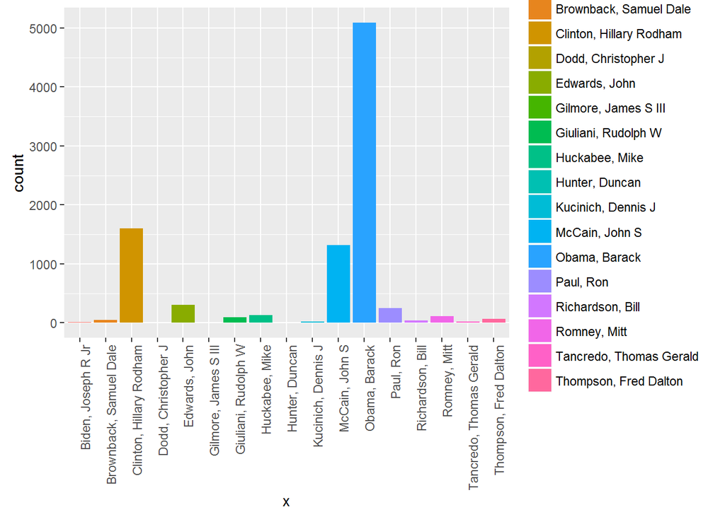

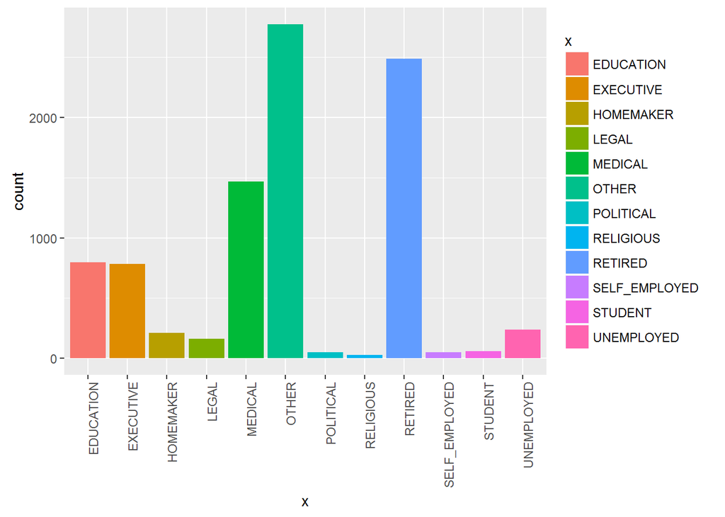

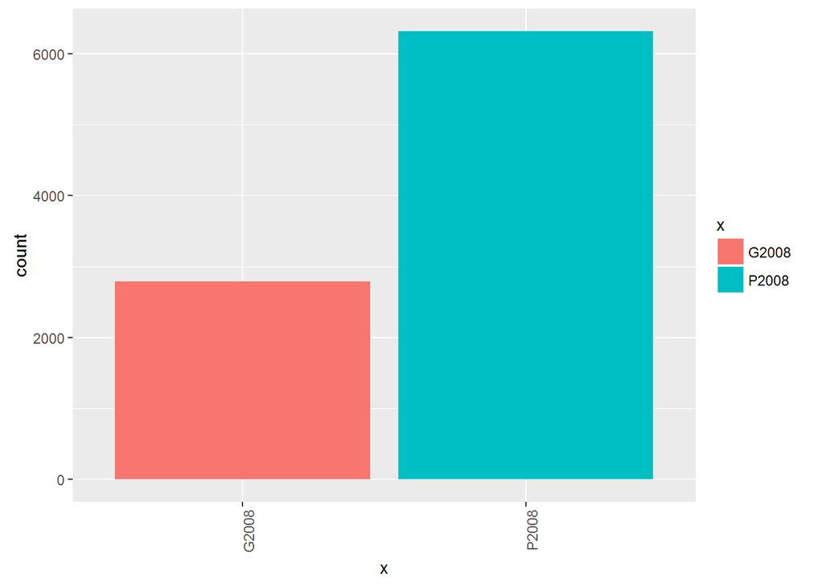

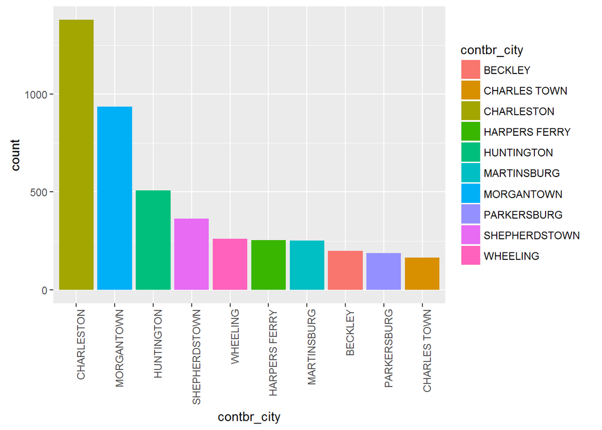

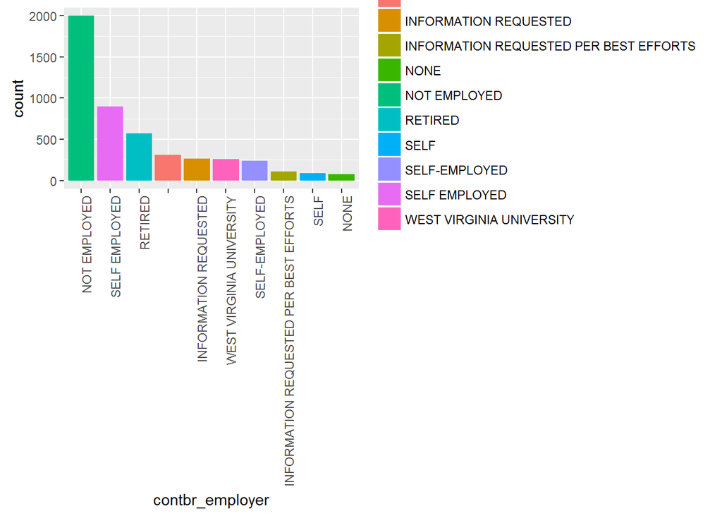

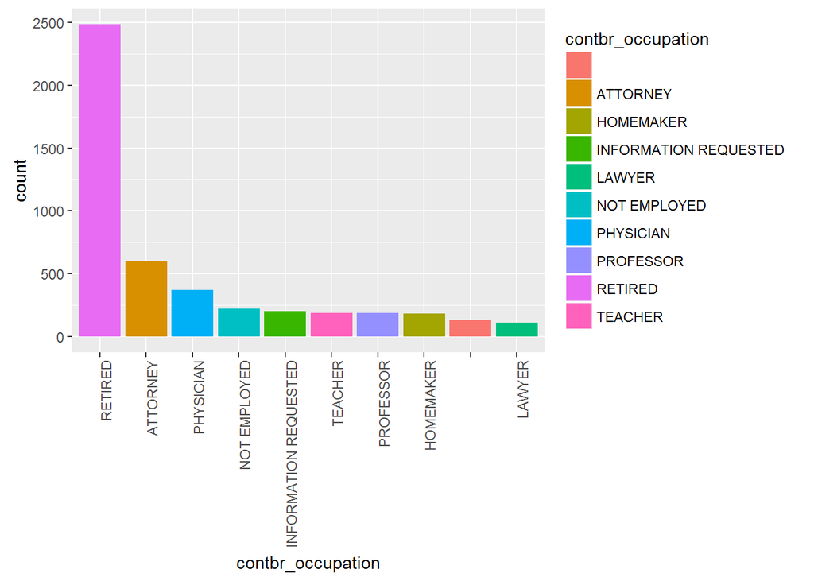

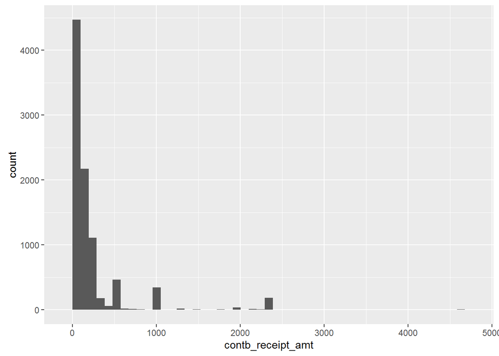

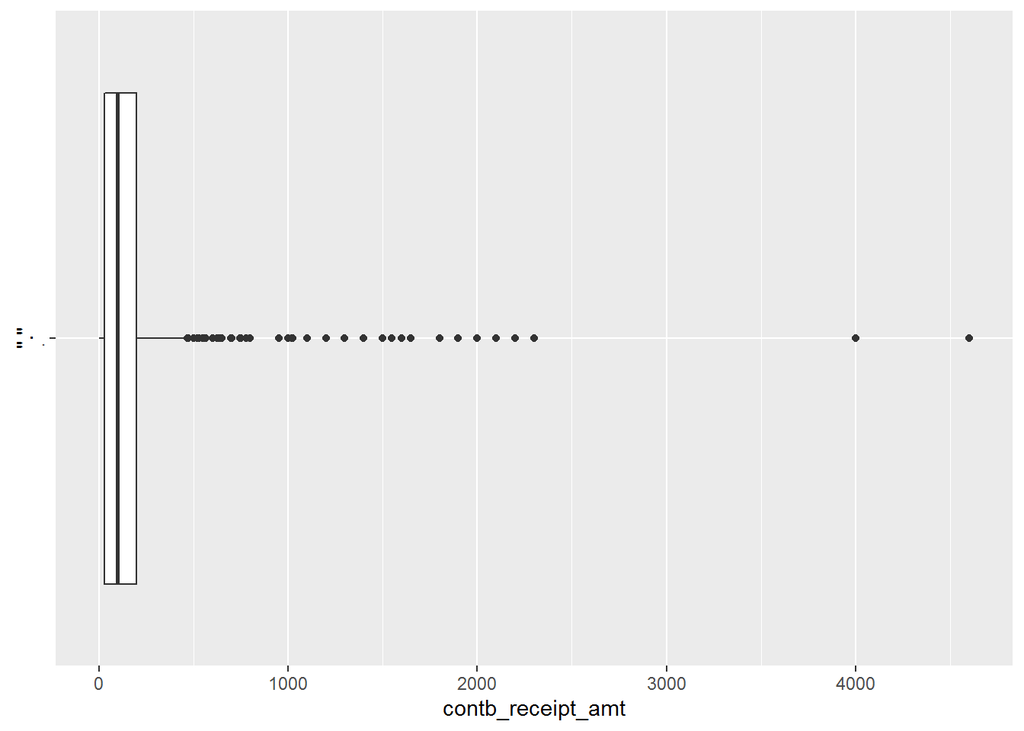

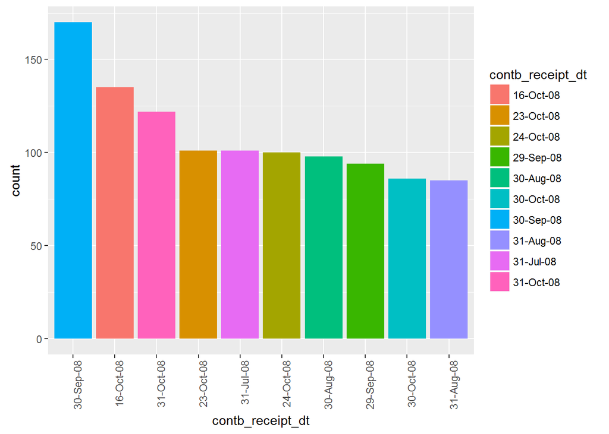

# Univariate Analysis

### What is the structure of your dataset?

The cleaned data includes information on 9109 individual contributions. There are 19 columns which are described here.

### What is/are the main feature(s) of interest in your dataset?

The main features of interest are the candidates, contributor occupations, contributor cities, contribution amounts, and contribution dates.

### What other features in the dataset do you think will help support your investigation into your feature(s) of interest?

Of the 17 candidates who received contributions in this data, only a handful are probably worth investigating. For example, there are only 3 candidates (Obama, McCain, and Clinton) who received over 10% of the total number of contributions. Only 5 other candidates received more than 1% of the total number of contributions. This could be an argument to only focus on the data for Obama, McCain, and Clinton. Another case for focusing on the main candidates would be that many of the other candidates dropped out early in the primary cycle. Edwards, Romney, and Huckabee dropped out in January, February, and March 2008, respectively ([Democratic Primary](https://en.wikipedia.org/wiki/Democratic_Party_presidential_primaries,_2008#Candidates_and_results) & [Republican Primary](https://en.wikipedia.org/wiki/Republican_Party_presidential_primaries,_2008#Candidates)). Republicans Brownback, Gilmore, and Tancredo who appear in the data withdrew before the primaries ([Withdrew before primaries](https://en.wikipedia.org/wiki/Republican_Party_presidential_primaries,_2008#Withdrew_before_primaries)). Other candidates in the data set have such a small amount of contributions to justify looking at the main candidates of Clinton, McCain, and Obama in later sections.

### Did you create any new variables from existing variables in the dataset?

Yes, during the cleaning and processing of the file, I decided to place the occupations into different bins. There were too many variations of different occupations, and I wanted to be able to do some analysis on occupation and its effect on contributions.

### Of the features you investigated, were there any unusual distributions? Did you perform any operations on the data to tidy, adjust, or change the form of the data? If so, why did you do this?

# Bivariate Plots Section

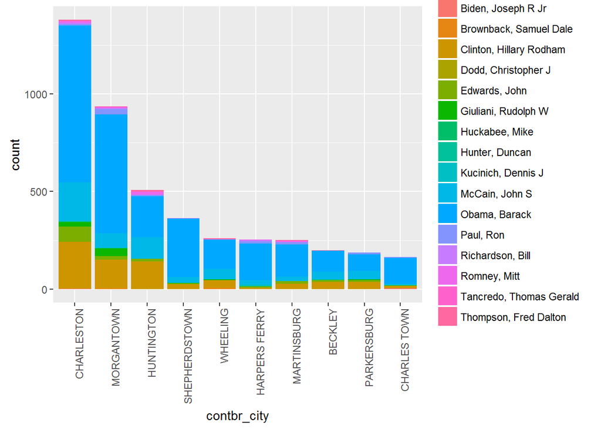

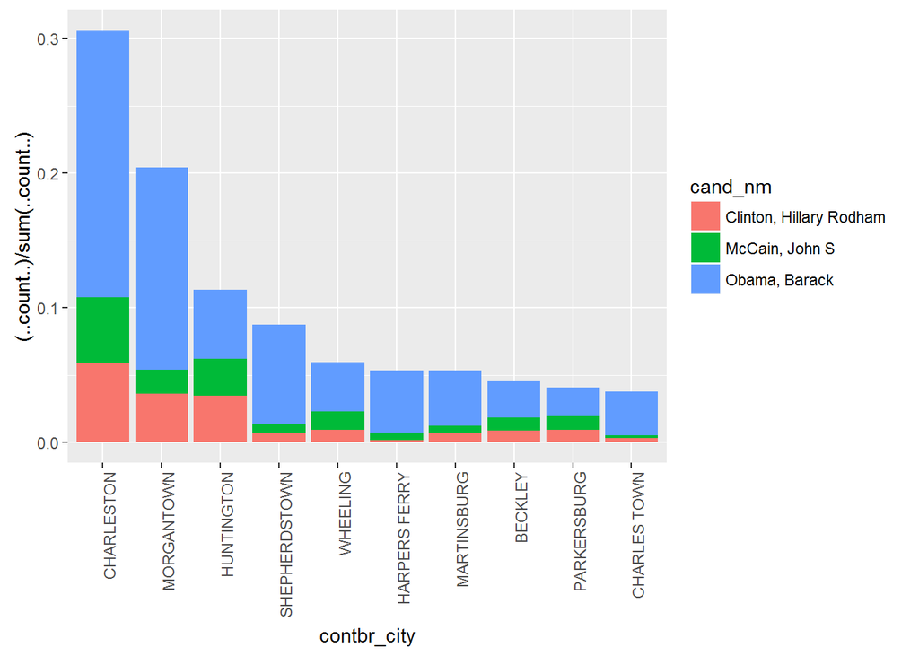

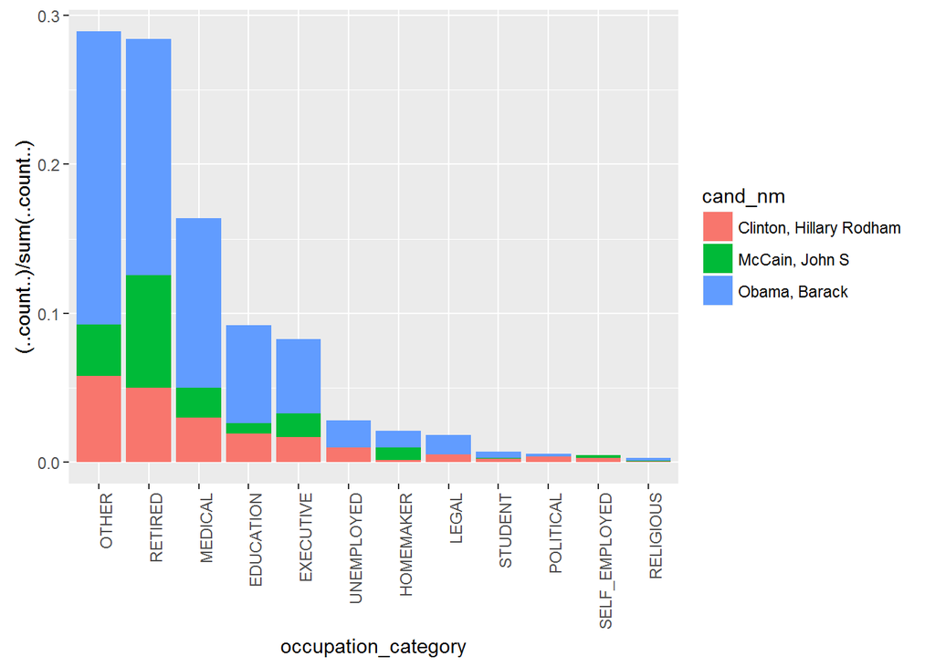

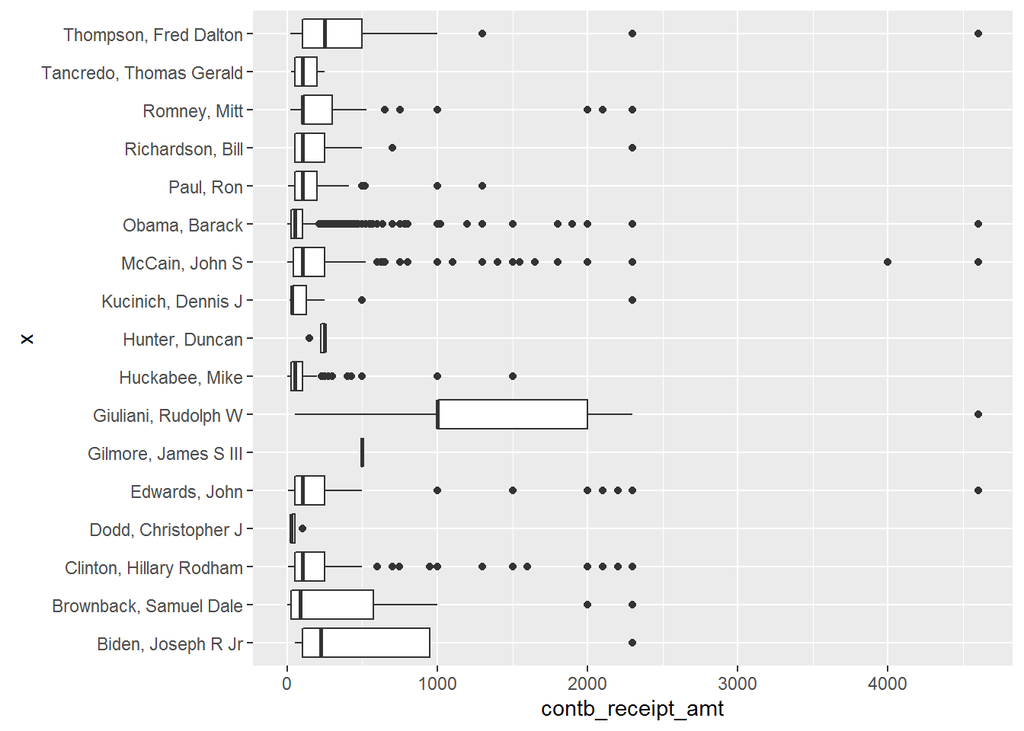

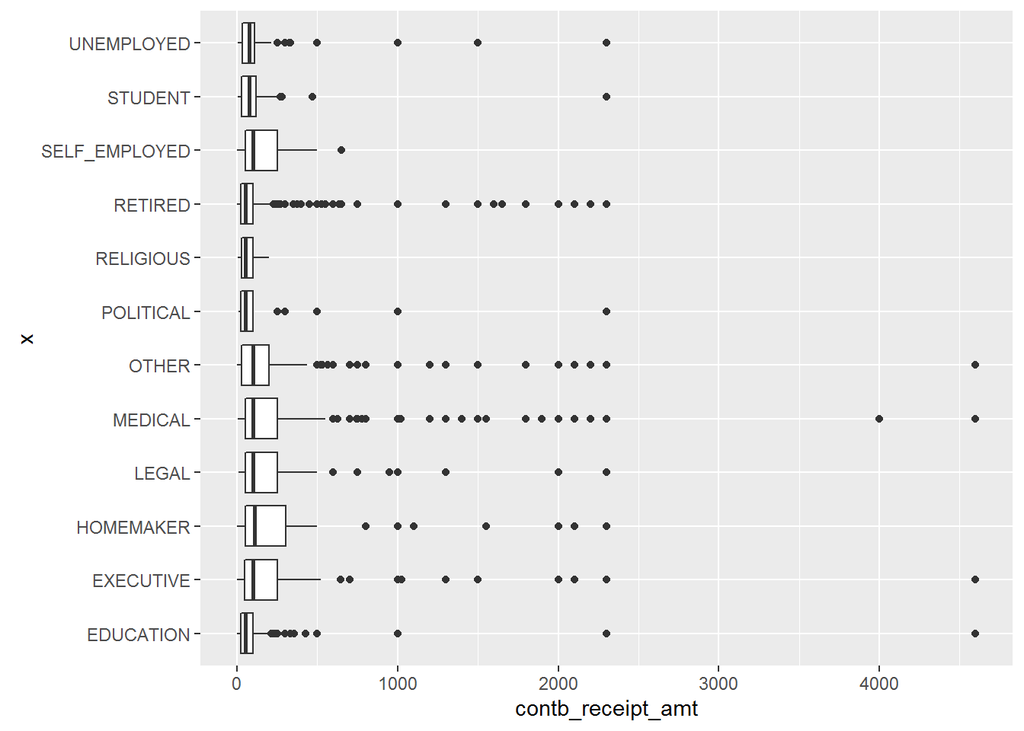

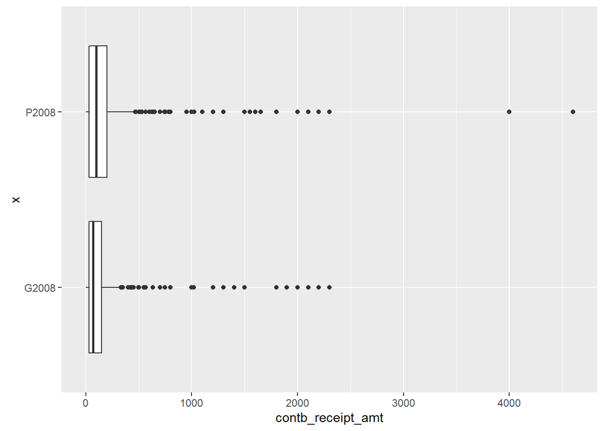

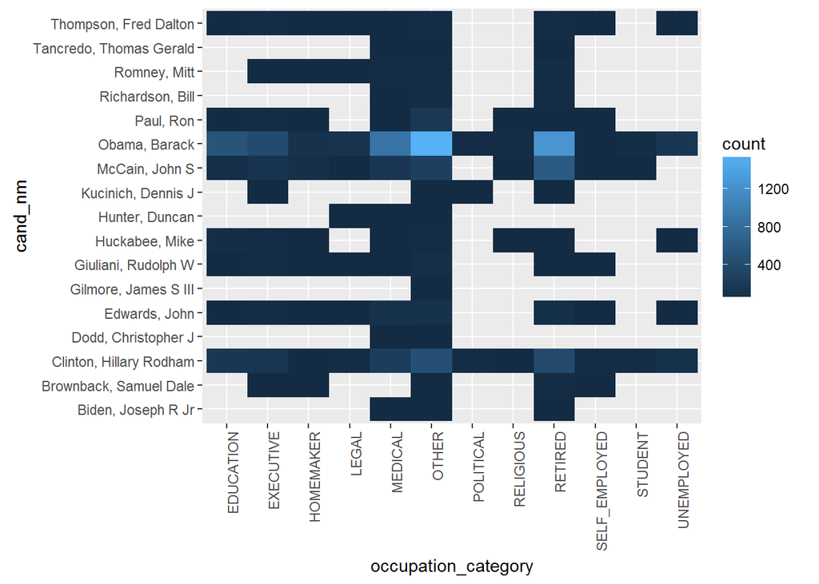

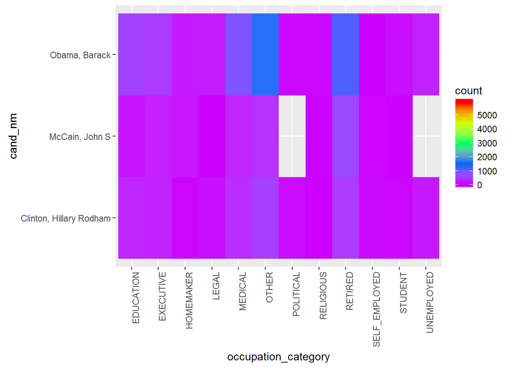

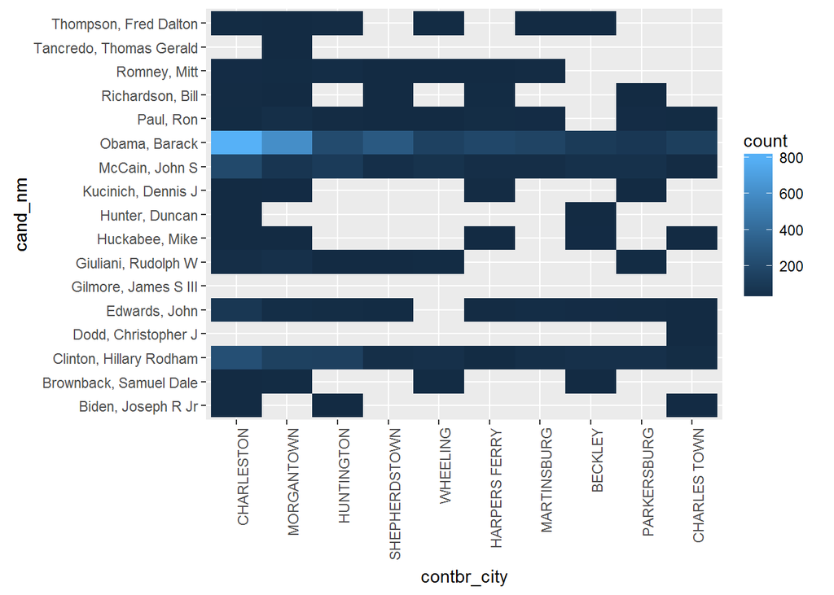

# Bivariate Analysis

### Talk about some of the relationships you observed in this part of the investigation. How did the feature(s) of interest vary with other features in the dataset?

### Did you observe any interesting relationships between the other features (not the main feature(s) of interest)?

### What was the strongest relationship you found?

# Multivariate Plots Section

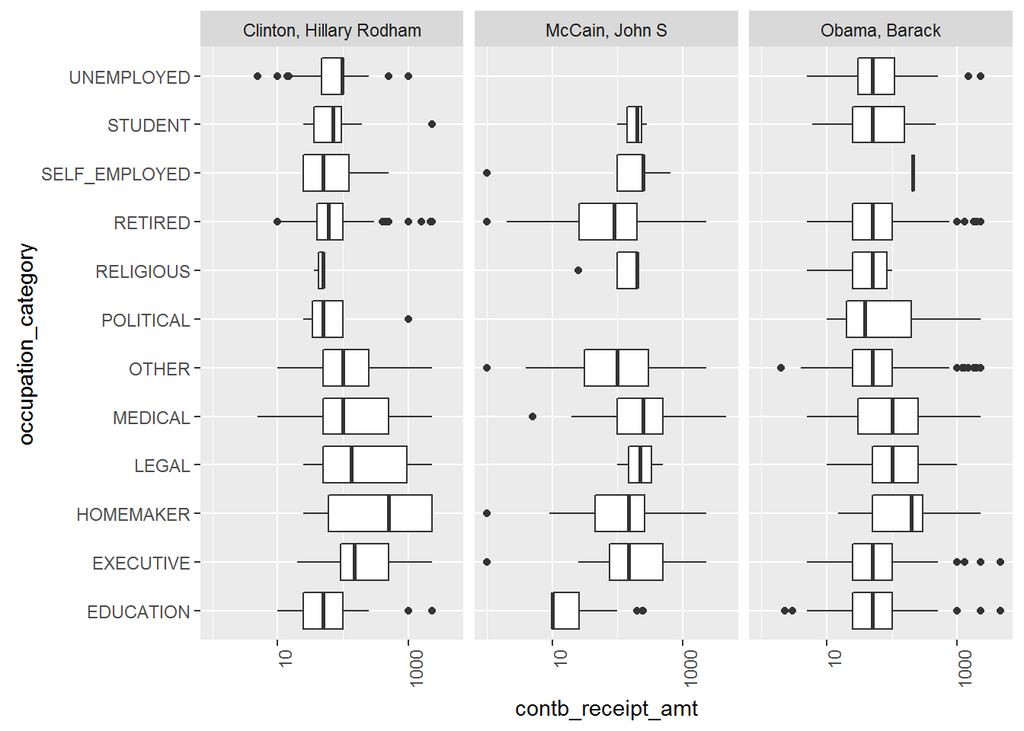

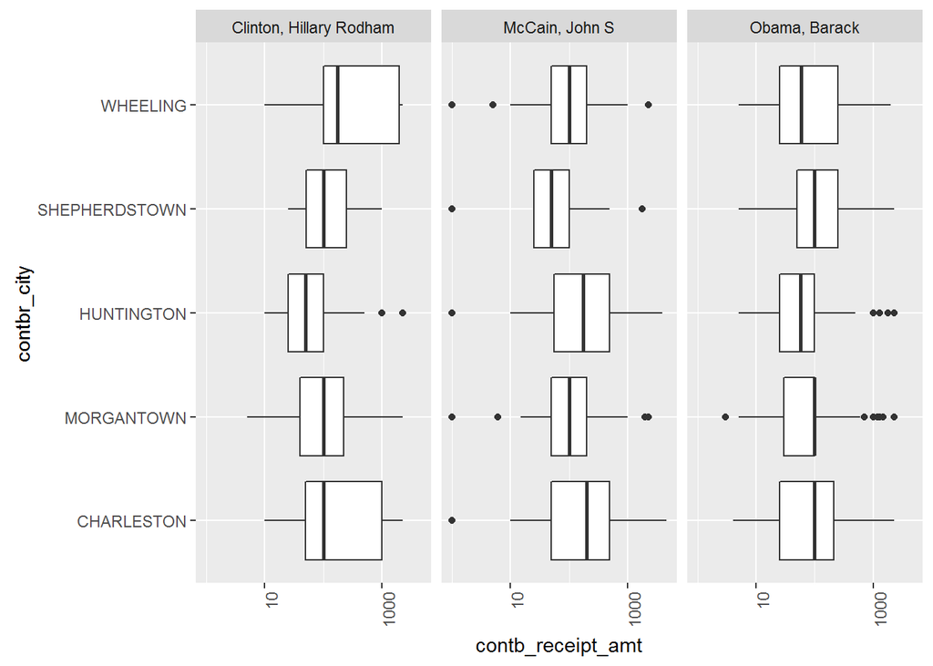

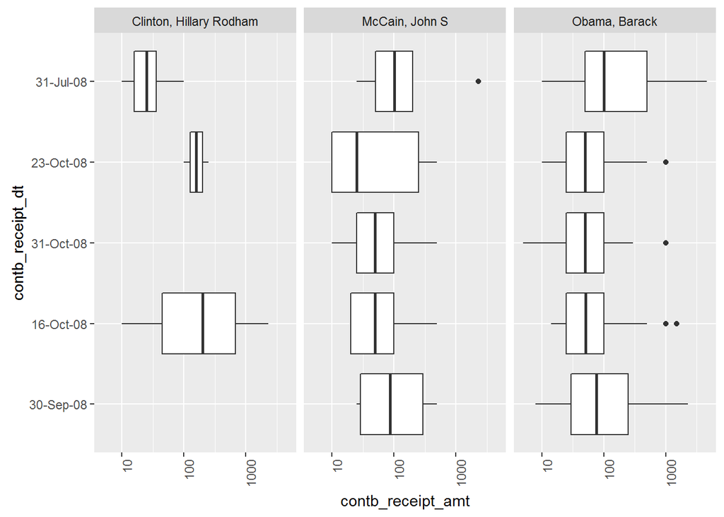

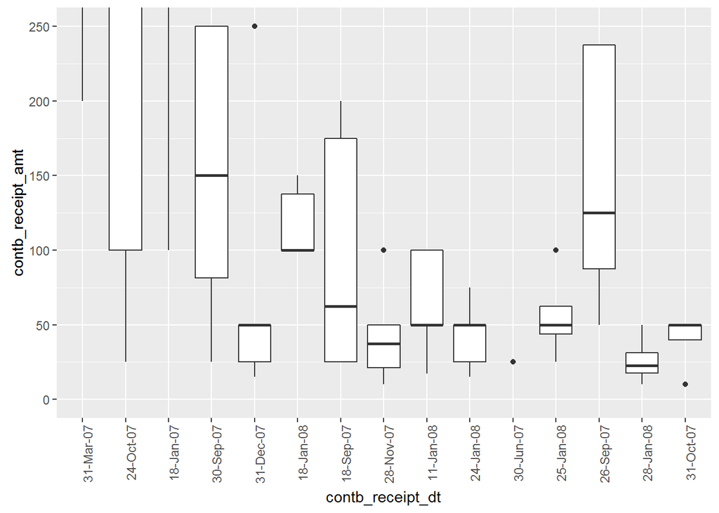

# Multivariate Analysis

### Talk about some of the relationships you observed in this part of the investigation. Were there features that strengthened each other in terms of looking at your feature(s) of interest?

### Were there any interesting or surprising interactions between features?

### OPTIONAL: Did you create any models with your dataset? Discuss the strengths and limitations of your model.

# Final Plots and Summary

### Plot One

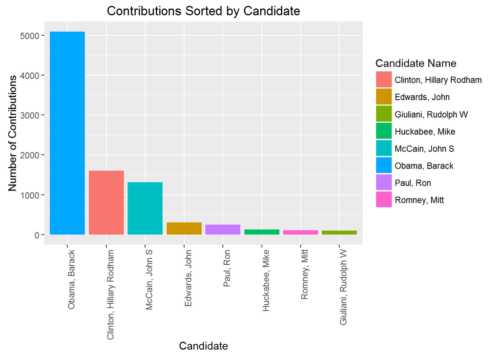

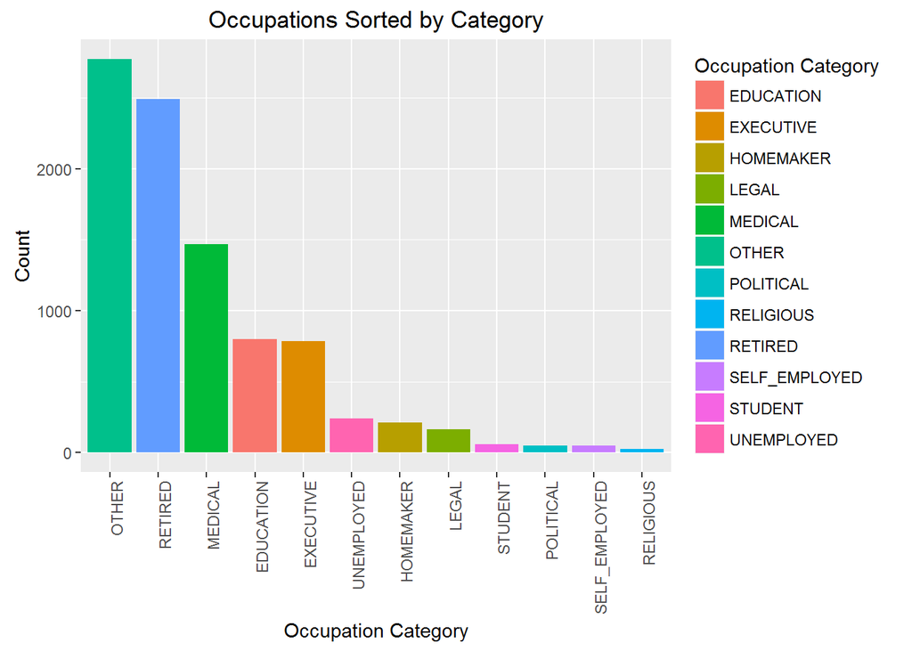

### Description One

### Plot Two

### Description Two

### Plot Three

### Description Three

# Reflection